# Forecasting of 5 Stock Exchanges with report

```r
install.packages("quantmod")
install.packages("ConnectednessApproach")
install.packages("urca")
install.packages("dynlm")
install.packages("egcm")
install.packages("quantmod")
```

```r
library(tseries)
library(fBasics)
library(tsDyn)

library(TSstudio)
library(rcompanion)
library(forecast)
library(lmtest)
library(forecast)
library(vars)
library(PerformanceAnalytics)
library(vrtest)
library(pracma)
library(rugarch)
library(FinTS)
library(e1071)
library(rmgarch)
library(devtools)
library(frequencyConnectedness)
library(ConnectednessApproach)
library(zoo)
library(urca)
library(dynlm)
library(egcm)
library(quantmod)
```

**Chosen 5 stock exchanges:**  
1. **^NSEI:** National Stock Exchange of India  
2. **^GSPC:** Standard & Poor’s 500 Index (S&P 500)  
3. **^HSI:** Hang Seng Index  
4. **^NYA:** New York Stock Exchange Composite Index  
5. **^N100:** Nasdaq 100 Index

**Importing all 5 stock exchanges**

```r
symbols <- c("^NSEI", "^GSPC", "^HSI","^NYA","^N100")
getSymbols(Symbols = symbols,
           src = 'yahoo',
           from = as.Date('2018-01-01'),
           to = as.Date('2023-12-31'),
           periodicity = 'daily')
```

```
[1] "NSEI" "GSPC" "HSI"  "NYA"  "N100"
```

**About chosen 5 stock excahnges:**

*1. National Stock Exchange of India (NSEI):*

The NSEI is the largest stock exchange in India by market capitalization. It is a fully electronic exchange that offers trading in equities, derivatives, debt instruments, and mutual funds. The NSEI has a wide range of products and services that cater to the needs of retail and institutional investors.

*2. Standard & Poor’s 500 Index (S&P 500):*

The S&P 500 is a stock market index that tracks the performance of 500 large companies listed on the New York Stock Exchange (NYSE) and the Nasdaq. It is widely considered to be a benchmark for the overall U.S. stock market. The S&P 500 is a popular index for investing and is tracked by many mutual funds and exchange-traded funds (ETFs).

*3. Hang Seng Index (HSI):*

The HSI is a stock market index that tracks the performance of the top 50 companies listed on the Hong Kong Stock Exchange (HKEX). It is the most widely tracked index in Hong Kong and is considered to be a benchmark for the Hong Kong stock market. The HSI is a popular index for investing and is tracked by many mutual funds and ETFs.

*4. New York Stock Exchange Composite Index (NYA):*

The NYA is a stock market index that tracks the performance of all common stocks listed on the New York Stock Exchange (NYSE). It is the oldest and largest stock exchange in the United States. The NYA is a popular index for investing and is tracked by many mutual funds and ETFs.

*5. Nasdaq 100 Index (N100):*

The N100 is a stock market index that tracks the performance of the 100 largest non-financial companies listed on the Nasdaq. It is a popular index for investing and is tracked by many mutual funds and ETFs. The N100 is particularly popular for investors who are interested in technology stocks, as many of the companies in the index are in the technology sector.

**Cleaning the data**

```r
#Removing nulls from closing price of data
NSEI <- na.omit(NSEI$NSEI.Close)
GSPC <- na.omit(GSPC$GSPC.Close)
HSI <- na.omit(HSI$HSI.Close)
NYA <- na.omit(NYA$NYA.Close)
N100 <- na.omit(N100$N100.Close)
```

**Taking log returns of data**

```r
#taking log returns
LRNSEI <- diff(log(NSEI))
LRGSPC <- diff(log(GSPC))
LRHSI <- diff(log(HSI))
LRNYA <- diff(log(NYA))
LRN100 <- diff(log(N100))
```

**Checking Stationarity of the Data:**

**Used Test:** Augmented Dicky Fuller’s Test

**H0:** The series is not stationary

**H1:** The series is stationary

1. **NSEI**

```r
#NSEI
#checking stationarity
LRNSEI <- diff(log(NSEI))
LRNSEI <- na.omit(LRNSEI)
adf.test(LRNSEI)
```

```
    Augmented Dickey-Fuller Test

data:  LRNSEI
Dickey-Fuller = -10.188, Lag order = 11, p-value = 0.01
alternative hypothesis: stationary
```

```r
#series is stationary
```

**Explanation:**

p-value = 0.01

p-value for NSEI is < 0.05

hence we reject the null hypothesis

hence NSEI returns series is stationary i.e. mean, variance, covariance remain constant over time and we can proceed ahead for time series analysis of the returns series

2. **GSPC**

```r
#GSPC
#checking stationarity
LRGSPC <- diff(log(GSPC))
LRGSPC <- na.omit(LRGSPC)
adf.test(LRGSPC)
```

```
    Augmented Dickey-Fuller Test

data:  LRGSPC
Dickey-Fuller = -10.808, Lag order = 11, p-value = 0.01
alternative hypothesis: stationary
```

```r
#series is stationary
```

**Explanation:**

p-value = 0.01

p-value for GSPC is < 0.05

hence we reject the null hypothesis

hence GSPC returns series is stationary i.e. mean, variance, covariance remain constant over time and we can proceed ahead for time series analysis of the returns series

3. **HSI**

```r
#HSI
#checking stationarity
LRHSI <- diff(log(HSI))
LRHSI <- na.omit(LRHSI)
adf.test(LRHSI)
```

```
    Augmented Dickey-Fuller Test

data:  LRHSI
Dickey-Fuller = -11.936, Lag order = 11, p-value = 0.01
alternative hypothesis: stationary
```

```r
#series is stationary
```

**Explanation:**

p-value = 0.01

p-value for HSI is < 0.05

hence we reject the null hypothesis

hence HSI returns series is stationary i.e. mean, variance, covariance remain constant over time and we can proceed ahead for time series analysis of the returns series

4. **NYA**

```r
#NYA
#checking stationarity
LRNYA <- diff(log(NYA))
LRNYA <- na.omit(LRNYA)
adf.test(LRNYA)
```

```
    Augmented Dickey-Fuller Test

data:  LRNYA
Dickey-Fuller = -10.899, Lag order = 11, p-value = 0.01
alternative hypothesis: stationary
```

```r
#series is stationary
```

**Explanation:**

p-value = 0.01

p-value for NYA is < 0.05

hence we reject the null hypothesis

hence NYA returns series is stationary i.e. mean, variance, covariance remain constant over time and we can proceed ahead for time series analysis of the returns series

5. **N100**

```r
#N100
#checking stationarity
LRN100 <- diff(log(N100))
LRN100 <- na.omit(LRN100)
adf.test(LRN100)
```

```
    Augmented Dickey-Fuller Test

data:  LRN100
Dickey-Fuller = -10.877, Lag order = 11, p-value = 0.01
alternative hypothesis: stationary
```

```r
#series is stationary
```

**Explanation:**

p-value = 0.01

p-value for N100 is < 0.05

hence we reject the null hypothesis

hence N100 returns series is stationary i.e. mean, variance, covariance remain constant over time and we can proceed ahead for time series analysis of the returns series

**Descriptives of 5 stock exchanges**

```r
#basic statistics
basicStats(LRNSEI)
```

|  | NSEI.Close |
| --- | --- |
| nobs | 1476.000000 |
| NAs | 0.000000 |
| Minimum | -0.139038 |
| Maximum | 0.084003 |
| 1. Quartile | -0.004703 |
| 3. Quartile | 0.006655 |
| Mean | 0.000497 |
| Median | 0.000963 |
| Sum | 0.732903 |
| SE Mean | 0.000301 |

[output cut: 6 more lines]

```r
basicStats(LRGSPC)
```

|  | GSPC.Close |
| --- | --- |
| nobs | 1508.000000 |
| NAs | 0.000000 |
| Minimum | -0.127652 |
| Maximum | 0.089683 |
| 1. Quartile | -0.005018 |
| 3. Quartile | 0.006913 |
| Mean | 0.000378 |
| Median | 0.000844 |
| Sum | 0.570612 |
| SE Mean | 0.000337 |

[output cut: 6 more lines]

```r
basicStats(LRHSI)
```

|  | HSI.Close |
| --- | --- |
| nobs | 1475.000000 |
| NAs | 0.000000 |
| Minimum | -0.065673 |
| Maximum | 0.086928 |
| 1. Quartile | -0.008375 |
| 3. Quartile | 0.007507 |
| Mean | -0.000395 |
| Median | 0.000145 |
| Sum | -0.582231 |
| SE Mean | 0.000376 |

[output cut: 6 more lines]

```r
basicStats(LRNYA)
```

|  | NYA.Close |
| --- | --- |
| nobs | 1508.000000 |
| NAs | 0.000000 |
| Minimum | -0.125950 |
| Maximum | 0.095642 |
| 1. Quartile | -0.004831 |
| 3. Quartile | 0.006124 |
| Mean | 0.000177 |
| Median | 0.000686 |
| Sum | 0.267084 |
| SE Mean | 0.000319 |

[output cut: 6 more lines]

```r
basicStats(LRN100)
```

|  | N100.Close |
| --- | --- |
| nobs | 1536.000000 |
| NAs | 0.000000 |
| Minimum | -0.127517 |
| Maximum | 0.078590 |
| 1. Quartile | -0.004679 |
| 3. Quartile | 0.006001 |
| Mean | 0.000197 |
| Median | 0.000837 |
| Sum | 0.303126 |
| SE Mean | 0.000297 |

[output cut: 6 more lines]

**Normality Test for all Series:**

**Used Test:** Jarque Bera Test

**H0:** The series is normally ditsributed

**H1:** The series is not normally distributed

```r
#Normality Test
jarque.bera.test(LRNSEI) #not normal
```

```
    Jarque Bera Test

data:  LRNSEI
X-squared = 30486, df = 2, p-value < 2.2e-16
```

```r
jarque.bera.test(LRGSPC) #not normal
```

```
    Jarque Bera Test

data:  LRGSPC
X-squared = 11983, df = 2, p-value < 2.2e-16
```

```r
jarque.bera.test(LRHSI) #not normal
```

```
    Jarque Bera Test

data:  LRHSI
X-squared = 507.86, df = 2, p-value < 2.2e-16
```

```r
jarque.bera.test(LRNYA) #not normal
```

```
    Jarque Bera Test

data:  LRNYA
X-squared = 19265, df = 2, p-value < 2.2e-16
```

```r
jarque.bera.test(LRN100) #not normal
```

```
    Jarque Bera Test

data:  LRN100
X-squared = 14220, df = 2, p-value < 2.2e-16
```

**Explanation:**

p-value for all 5 series is less than 0.05

hence we reject the null hypothesis and say that all the series are not normally distributed

Implication: all the 5 return series are risky stock exchanges

**Plotting all the 5 stock exchanges**

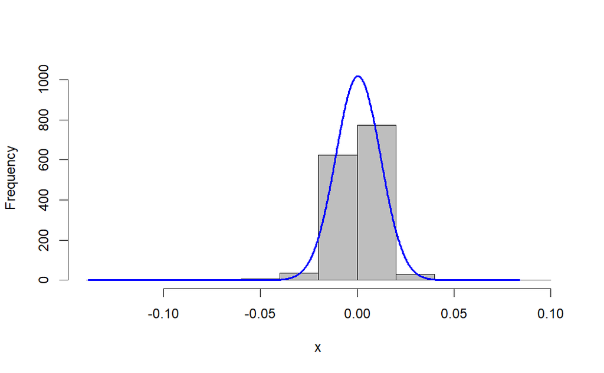

```r
plotNormalHistogram(LRNSEI)
```

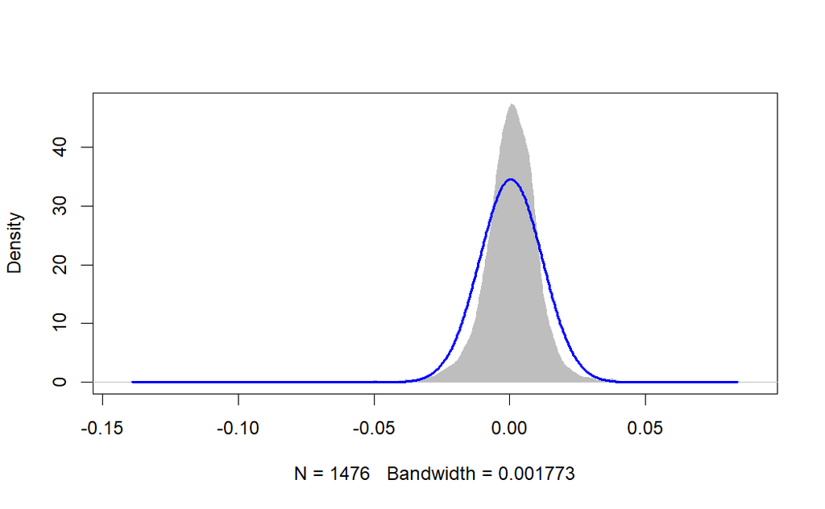

```r
plotNormalDensity(LRNSEI)
```

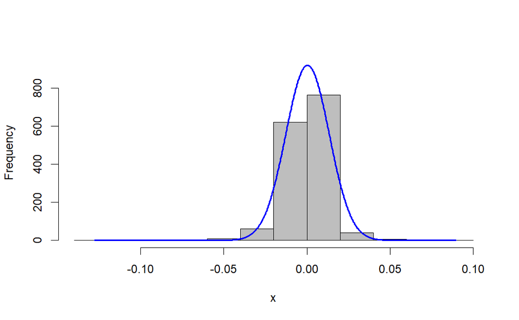

```r
plotNormalHistogram(LRGSPC)
```

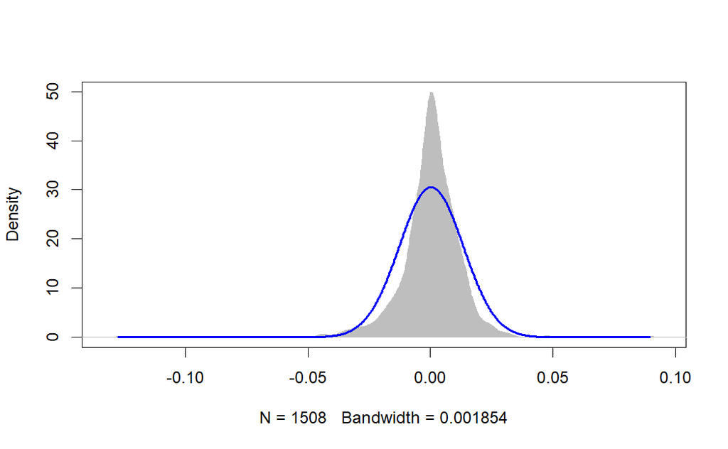

```r
plotNormalDensity(LRGSPC)
```

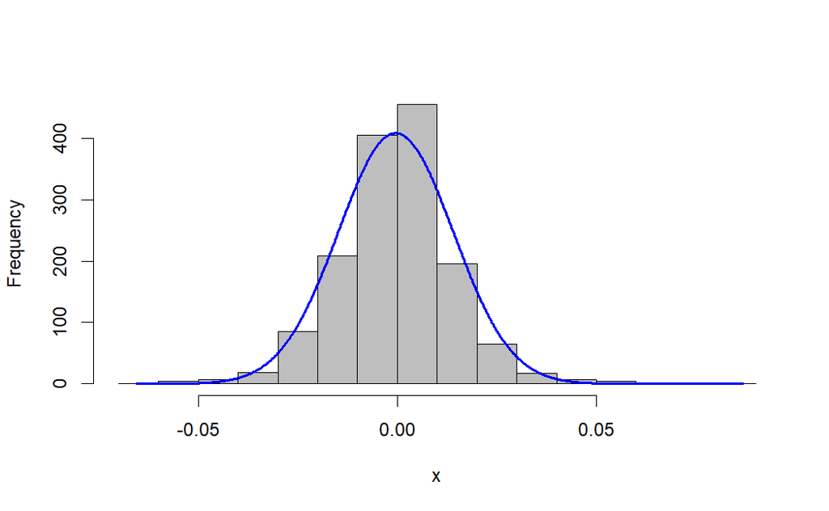

```r
plotNormalHistogram(LRHSI)
```

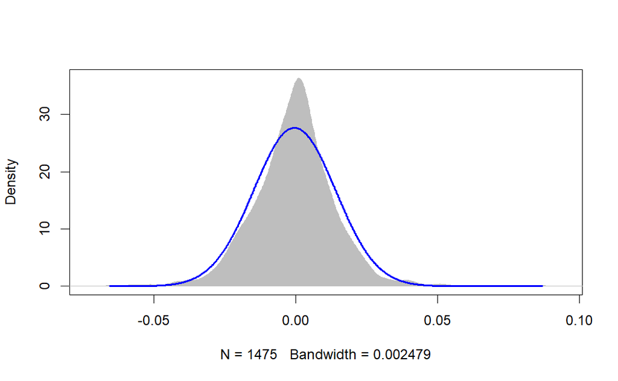

```r
plotNormalDensity(LRHSI)
```

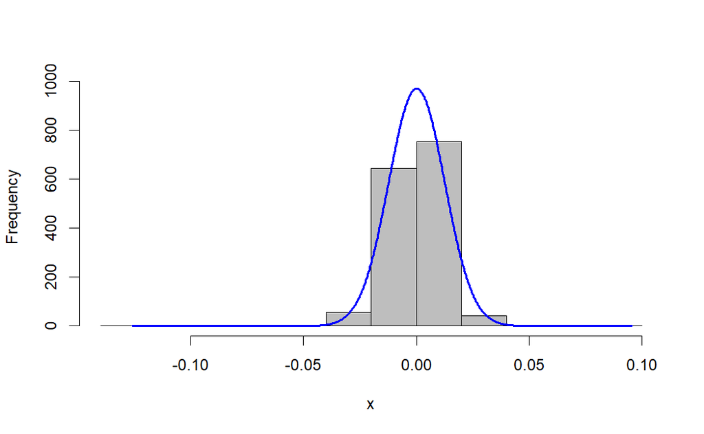

```r
plotNormalHistogram(LRNYA)
```

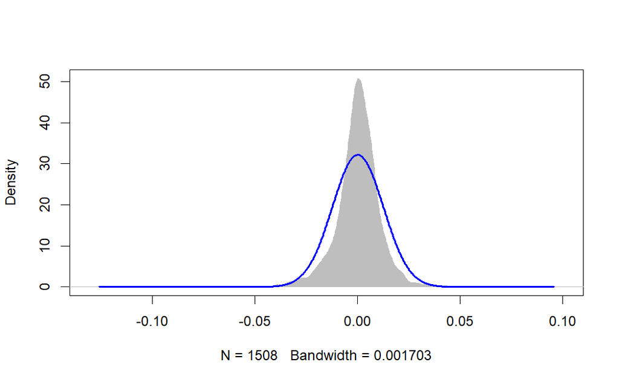

```r
plotNormalDensity(LRNYA)
```

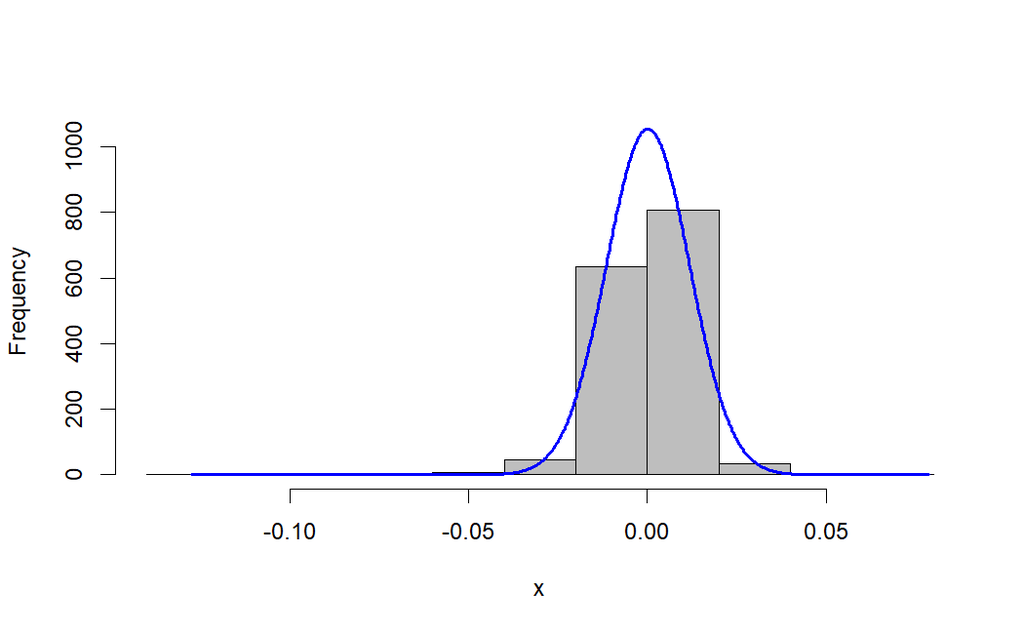

```r
plotNormalHistogram(LRN100)
```

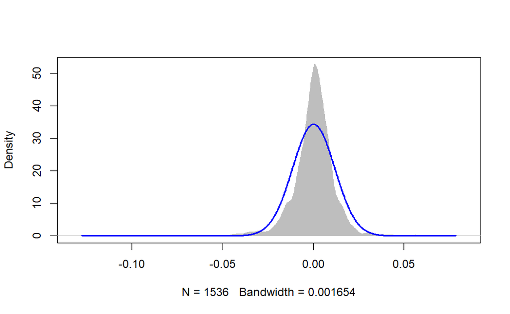

```r
plotNormalDensity(LRN100)
```

**ARIMA Modelling of Returns Series:**

1. **NSEI:**

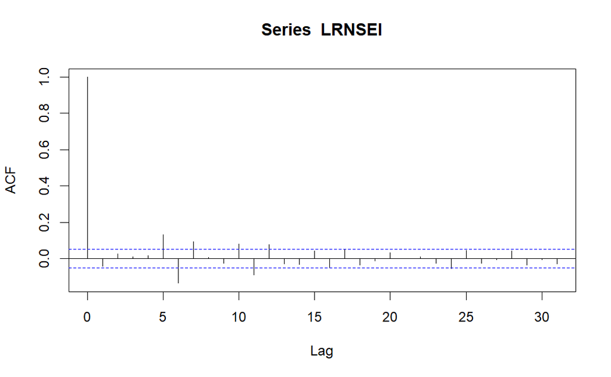

```r
#Plotting ACF & PACF plot
acf(LRNSEI)
```

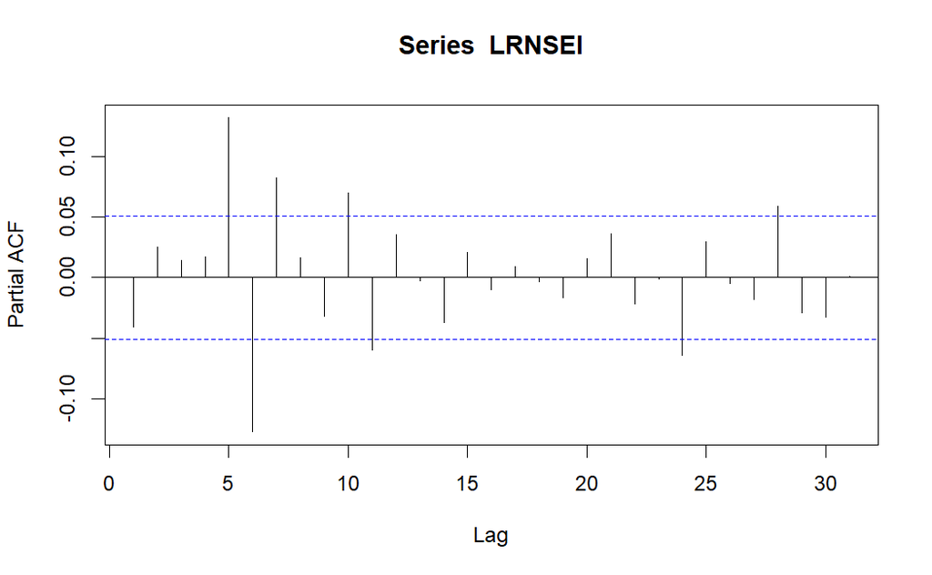

```r
pacf(LRNSEI)
```

```r
#Using Auto arima to decide the order of series
arma_pq_LRNSEI = auto.arima(LRNSEI)
arma_pq_LRNSEI
```

```
Series: LRNSEI
ARIMA(0,0,1) with non-zero mean

Coefficients:
          ma1   mean
      -0.0388  5e-04
s.e.   0.0253  3e-04

sigma^2 = 0.0001337:  log likelihood = 4489.62
AIC=-8973.24   AICc=-8973.23   BIC=-8957.35
```

```r
#Application of ARIMA
model1 = arima(LRNSEI,order = c(0,0,1))
model1
```

```
Call:
arima(x = LRNSEI, order = c(0, 0, 1))

Coefficients:
          ma1  intercept
      -0.0388      5e-04
s.e.   0.0253      3e-04

sigma^2 estimated as 0.0001335:  log likelihood = 4489.62,  aic = -8973.24
```

```r
et = residuals(model1)
et
```

```
Time Series:
Start = 1
End = 1476
Frequency = 1
   [1] -4.004983e-04  5.369096e-03  4.844066e-03  5.805184e-03  9.895340e-04 -9.094597e-04
   [7]  1.253539e-03  2.369422e-03  5.224995e-03 -4.127155e-03  7.542667e-03  2.430047e-03
  [13]  6.755317e-03  6.307241e-03  1.040620e-02  1.151549e-04 -1.967974e-03  4.899964e-03
  [19] -7.587565e-03 -2.779792e-03 -1.584360e-03 -2.409732e-02 -1.021128e-02 -1.679731e-02
  [25] -3.203890e-03  8.892831e-03 -1.174315e-02  7.125515e-03 -3.912579e-03  3.589673e-03
  [31] -9.234313e-03 -7.950551e-03 -2.541288e-03  2.974438e-03 -1.800639e-03  9.815006e-03
  [37]  8.573328e-03 -2.841283e-03 -6.446240e-03 -4.040345e-03 -1.021299e-02 -1.152996e-02
  [43] -1.026156e-02  7.777796e-03 -1.738259e-03  1.828076e-02  7.363311e-04 -1.998758e-03
  [49] -5.460824e-03 -1.676329e-02 -1.109395e-02  2.049899e-03  2.630508e-03 -4.390434e-03
  [55] -1.227181e-02  1.220219e-02  5.244558e-03 -7.234498e-03  8.875340e-03  3.094100e-03
  [61] -1.182275e-02  1.828347e-02  8.381034e-04  4.147092e-03  1.868450e-03  1.007417e-03
```

[output cut: 157 more lines]

```r
#Checking of significance of ARMA
coeftest(model1)
```

```
z test of coefficients:

             Estimate  Std. Error z value Pr(>|z|)
ma1       -0.03884638  0.02529109 -1.5360  0.12455
intercept  0.00049656  0.00029024  1.7108  0.08711 .
---
Signif. codes:  0 ‘***’ 0.001 ‘**’ 0.01 ‘*’ 0.05 ‘.’ 0.1 ‘ ’ 1
```

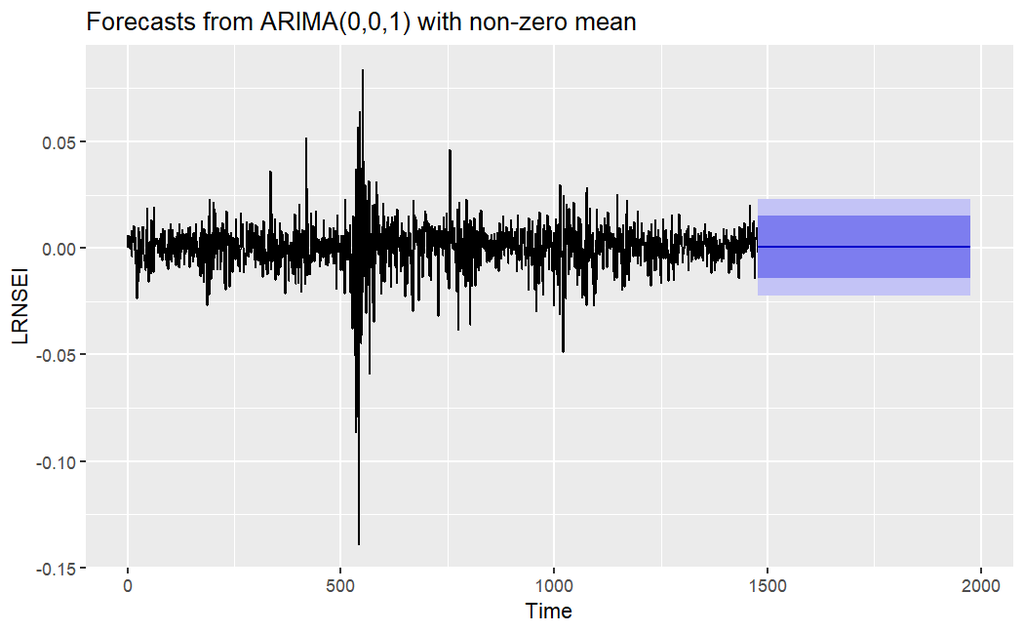

```r
#point forecast is called out of sample forecast
autoplot(forecast(model1, h=500))
```

```
    Ljung-Box test

data:  Residuals from ARIMA(0,0,1) with non-zero mean
Q* = 71.661, df = 9, p-value = 7.187e-12

Model df: 1.   Total lags used: 10
```

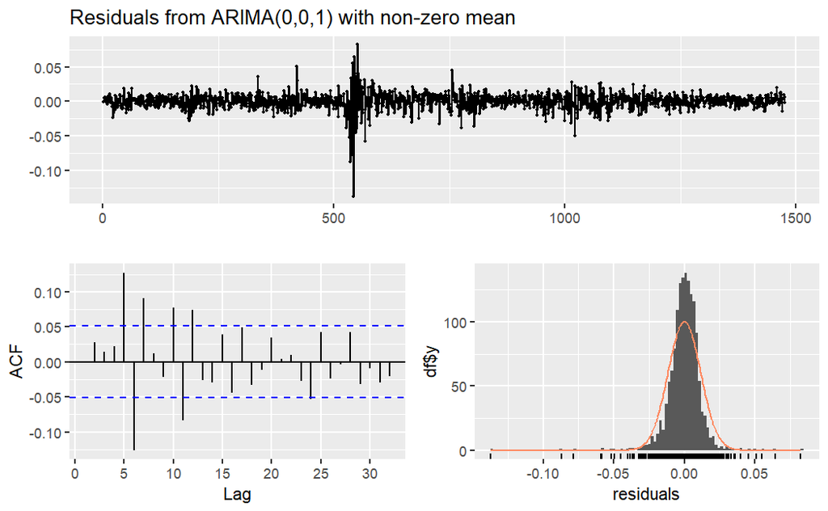

```r
#checking autocorrelation in error term
checkresiduals(model1) #there is autocorrelation in the error term
```

**Explanation:**

1. **Auto ARIMA:** gave order of ARIMA (0,0,1)

   i.e. no autoregressive (AR) terms, no differencing (D) terms, and one moving average (MA) term.
2. **Log likelihood:** 4489.62. This is a measure of the model’s goodness of fit. A higher log likelihood indicates a better fit.

   **AIC:** -8973.24. The Akaike Information Criterion (AIC) is a measure of model complexity and fit. A lower AIC indicates a better model.

   **sigma^2:** 0.0001335. This is the estimated variance of the residuals, representing the model’s ability to fit the data. A smaller value suggests a better fit.

   **Implication:** The ARIMA(0,0,1) model provides a parsimonious representation of the LRNSEI time series. The model suggests that the current value of the series is influenced by the previous period’s error.
3. **The significance test** indicate that the MA1 coefficient in the ARIMA(0,0,1) model is not statistically significant. The intercept coefficient is close to being statistically significant, but more evidence is needed to confirm its significance.
4. **Autocorrelation Test:**

   Ljung Box Test:

   H0: There is no autocorrelation in error term

   H1: There is autocorrelation in error term

   p-value < 0.05 suggests that there is autocorrelation in error term of the series.

2. **GSPC:**

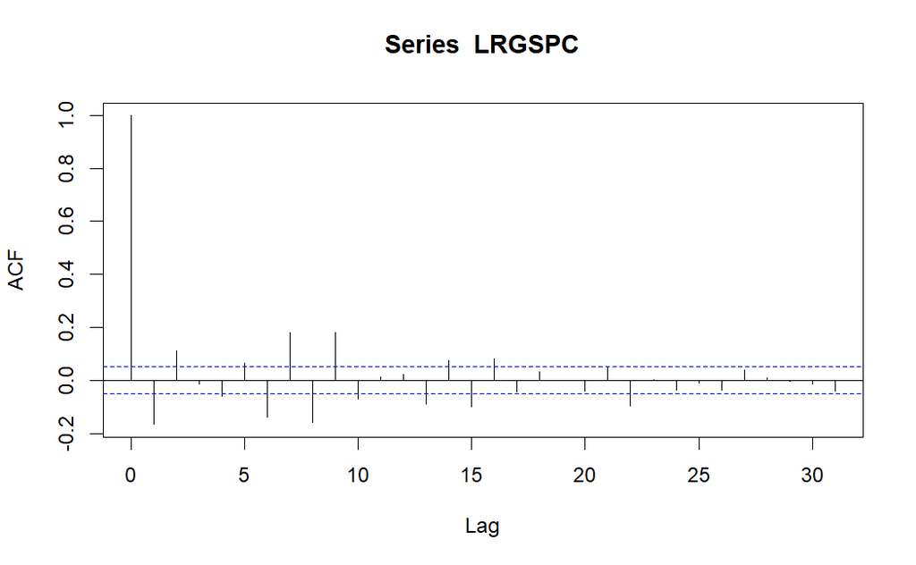

```r
acf(LRGSPC)
```

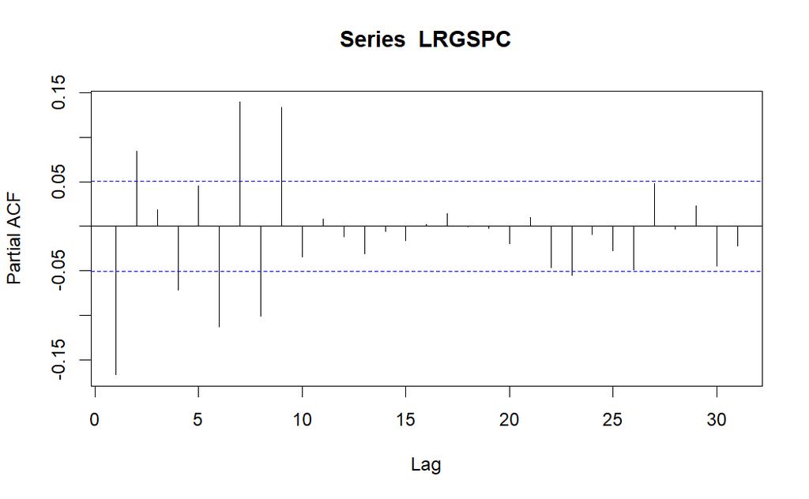

```r
pacf(LRGSPC)
```

```r
#Using Auto arima
arma_pq_LRGSPC = auto.arima(LRGSPC)
arma_pq_LRGSPC
```

```
Series: LRGSPC
ARIMA(4,0,4) with zero mean

Coefficients:
          ar1     ar2      ar3      ar4     ma1      ma2     ma3     ma4
      -0.2431  0.7515  -0.3713  -0.8419  0.1408  -0.7099  0.4569  0.6795
s.e.   0.0391  0.0390   0.0352   0.0371  0.0510   0.0483  0.0442  0.0483

sigma^2 = 0.0001553:  log likelihood = 4476.69
AIC=-8935.38   AICc=-8935.26   BIC=-8887.52
```

```r
#Application of ARIMA

model2 = arima(LRNSEI,order = c(4,0,4))
model2
```

```
Call:
arima(x = LRNSEI, order = c(4, 0, 4))

Coefficients:
          ar1     ar2     ar3      ar4      ma1      ma2      ma3     ma4  intercept
      -0.0263  0.7629  0.5177  -0.5419  -0.0203  -0.6764  -0.5065  0.5297      5e-04
s.e.   0.6010  0.3588  0.2993   0.5198   0.6091   0.3382   0.2716  0.5097      3e-04

sigma^2 estimated as 0.0001281:  log likelihood = 4519.7,  aic = -9019.39
```

```r
et = residuals(model2)
et
```

```
Time Series:
Start = 1
End = 1476
Frequency = 1
   [1] -3.831823e-04  5.267342e-03  4.964548e-03  5.371773e-03  6.991719e-04 -1.311723e-03
   [7]  7.426540e-04  2.375714e-03  4.655021e-03 -4.288103e-03  6.937367e-03  2.578665e-03
  [13]  6.050028e-03  5.854364e-03  1.016161e-02 -1.012141e-03 -2.635850e-03  4.387228e-03
  [19] -7.992555e-03 -3.626633e-03 -1.160277e-03 -2.420611e-02 -1.065385e-02 -1.416423e-02
  [25] -3.366982e-03  1.098424e-02 -9.954035e-03  5.809676e-03 -1.011425e-04  2.093474e-03
  [31] -8.370670e-03 -6.297910e-03 -4.171793e-03  5.997464e-03 -2.723293e-03  9.752850e-03
  [37]  1.071459e-02 -5.562739e-03 -5.315029e-03 -4.036064e-03 -1.139761e-02 -9.652769e-03
  [43] -1.103916e-02  9.175516e-03 -1.469621e-04  1.683152e-02  3.254951e-03 -4.013886e-03
  [49] -5.342402e-03 -1.530276e-02 -1.338707e-02  5.318294e-03  2.373655e-03 -4.903326e-03
  [55] -9.817131e-03  1.068058e-02  7.884585e-03 -8.139078e-03  7.976013e-03  6.060762e-03
  [61] -1.519507e-02  1.970078e-02  2.241440e-03 -3.908583e-05  5.085590e-03 -1.289366e-03
```

[output cut: 157 more lines]

```r
#Checking of significance of ARMA
coeftest(model2)
```

```
z test of coefficients:

             Estimate  Std. Error z value Pr(>|z|)
ar1       -0.02627093  0.60102255 -0.0437  0.96514
ar2        0.76293223  0.35875370  2.1266  0.03345 *
ar3        0.51771203  0.29934677  1.7295  0.08372 .
ar4       -0.54187477  0.51975697 -1.0426  0.29715
ma1       -0.02034714  0.60906988 -0.0334  0.97335
ma2       -0.67639995  0.33817324 -2.0002  0.04548 *
ma3       -0.50646848  0.27164249 -1.8645  0.06226 .
ma4        0.52971353  0.50970032  1.0393  0.29868
intercept  0.00048713  0.00033547  1.4521  0.14647
---
Signif. codes:  0 ‘***’ 0.001 ‘**’ 0.01 ‘*’ 0.05 ‘.’ 0.1 ‘ ’ 1
```

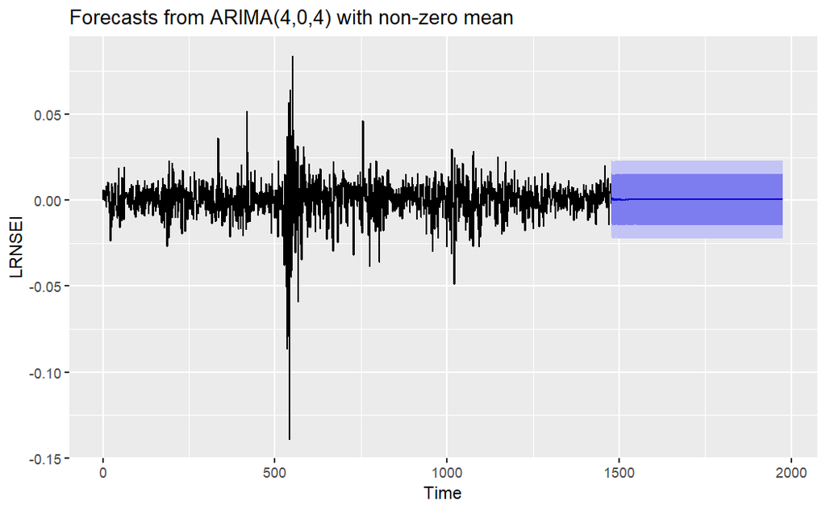

```r
#point forecast is called out of sample forecast
autoplot(forecast(model2, h=500))
```

```r
#checking autocorrelation in error term
checkresiduals(model2) #there is autocorrelation in the error term
```

```
    Ljung-Box test

data:  Residuals from ARIMA(4,0,4) with non-zero mean
Q* = 24.858, df = 3, p-value = 1.653e-05

Model df: 8.   Total lags used: 11
```

```r
install.packages("quantmod")
install.packages("ConnectednessApproach")
install.packages("quantmod")
```

[output not shown]

```r
install.packages("frequencyConnectedness")
```

[output not shown]

```r
install.packages("urca")
```

[output not shown]

```r
install.packages("dynlm")
```

[output not shown]

```r
install.packages("egcm")
```

[output not shown]

```r
install.packages("rmgarch")
```

[output not shown]

```r
install.packages("e1071")
```

[output not shown]

```r
install.packages("devtools")
```

[output not shown]

```r
install.packages("rugarch")
```

[output not shown]

```r
install.packages("FinTS")
```

[output not shown]

```r
install.packages("pracma")
```

[output not shown]

```r
install.packages("PerformanceAnalytics")
```

[output not shown]

```r
install.packages("fBasics")
```

[output not shown]

```r
install.packages("tseries")
```

**Explanation:**

1. **Auto ARIMA:** gave order of ARIMA (4,0,4)

   i.e. 4th autoregressive (AR) order, no differencing (D) terms, and fourth moving average (MA) term.
2. **sigma^2:** 0.0001281. This is the estimated variance of the residuals, representing the model’s ability to fit the data.

   **Log likelihood:** 4519.7. A higher log likelihood indicates a better fit.

   **AIC:** -9019.39. A lower AIC indicates a better model.

   Ljung Box Test:

   H0: There is no autocorrelation in error term

   H1: There is autocorrelation in error term

   p-value < 0.05 suggests that there is autocorrelation in error term of the series.
3. **HSI:**

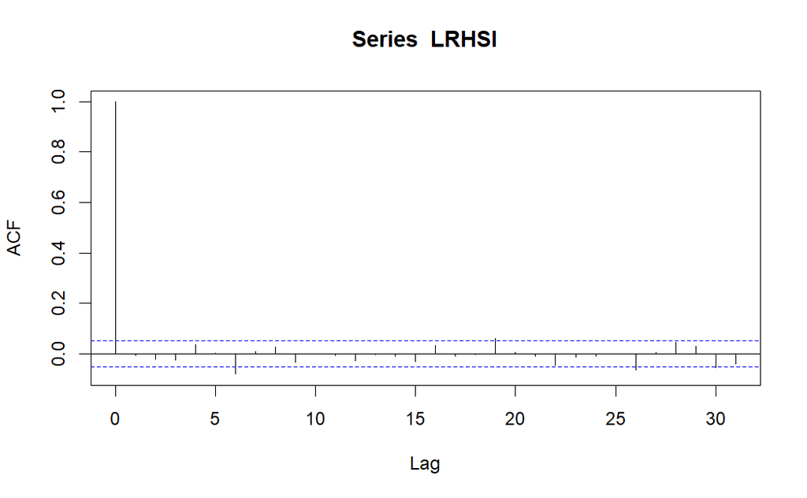

```r
acf(LRHSI)
```

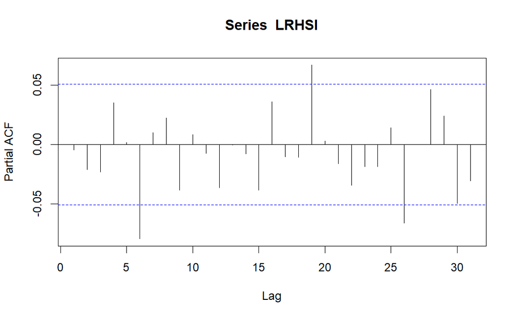

```r
pacf(LRHSI)
```

```r
#Using Auto arima
arma_pq_LRHSI = auto.arima(LRHSI)
arma_pq_LRHSI
```

```
Series: LRHSI
ARIMA(0,0,0) with zero mean

sigma^2 = 0.000208:  log likelihood = 4159.46
AIC=-8316.92   AICc=-8316.92   BIC=-8311.62
```

```r
#Application of ARIMA

model3 = arima(LRHSI,order = c(0,0,0))
model3
```

```
Call:
arima(x = LRHSI, order = c(0, 0, 0))

Coefficients:
      intercept
         -4e-04
s.e.      4e-04

sigma^2 estimated as 0.0002079:  log likelihood = 4160.01,  aic = -8316.03
```

```r
et = residuals(model3)
et
```

```
Time Series:
Start = 1
End = 1475
Frequency = 1
   [1]  1.889215e-03  6.121947e-03  2.934417e-03  3.145762e-03  4.008989e-03  2.401995e-03
   [7]  1.895516e-03  9.738628e-03 -1.953261e-03  1.829048e-02  2.857167e-03  4.716666e-03
  [13]  4.525143e-03  4.680066e-03  1.684505e-02  1.244405e-03 -8.879152e-03  1.558064e-02
  [19] -5.268549e-03 -1.057316e-02  8.944517e-03 -7.088350e-03 -8.409554e-04 -1.060230e-02
  [25] -5.212478e-02 -8.542519e-03  4.609348e-03 -3.109120e-02 -1.226141e-03  1.320785e-02
  [31]  2.279875e-02  1.986055e-02 -7.406645e-03  1.831529e-02 -1.454879e-02  1.008391e-02
  [37]  7.769158e-03 -6.932032e-03 -1.325598e-02  6.842731e-03 -1.455989e-02 -2.266104e-02
  [43]  2.106996e-02 -9.943777e-03  1.543491e-02  1.147959e-02  1.950744e-02  6.200375e-04
  [49] -4.886015e-03  3.763946e-03 -8.466059e-04  7.688957e-04  1.541825e-03 -3.906436e-03
  [55] -1.059892e-02 -2.442757e-02  8.264905e-03  8.287246e-03 -2.487411e-02  2.751899e-03
  [61]  3.272244e-03 -2.176442e-02  1.138642e-02  1.320036e-02  1.677220e-02  5.878454e-03
```

[output cut: 157 more lines]

```r
install.packages("tseries")
install.packages("fBasics")
install.packages("rugarch")
install.packages("rmgarch")
install.packages("devtools")
install.packages("PerformanceAnalytics")
install.packages("FinTS")
```

[output not shown]

```r
install.packages("e1071")
```

[output not shown]

```r
install.packages("pracma")
```

[output not shown]

```r
install.packages("egcm")
```

[output not shown]

```r
install.packages("dynlm")
```

[output not shown]

```r
install.packages("frequencyConnectedness")
```

[output not shown]

```r
install.packages("urca")
```

[output not shown]

```r
install.packages("quantmod")
```

[output not shown]

```r
#Checking of significance of ARMA
coeftest(model3)
```

```
z test of coefficients:

             Estimate  Std. Error z value Pr(>|z|)
intercept -0.00039473  0.00037631  -1.049   0.2942
```

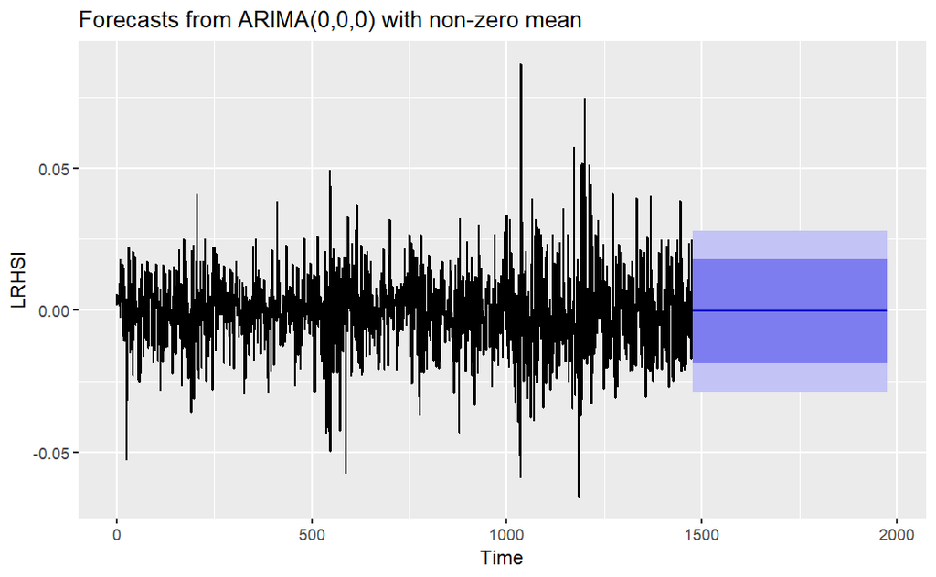

```r
#point forecast is called out of sample forecast
autoplot(forecast(model3, h=500))
```

```r
#checking autocorrelation in error term
checkresiduals(model3) #there is no autocorrelation in the error term
```

```
    Ljung-Box test

data:  Residuals from ARIMA(0,0,0) with non-zero mean
Q* = 15.952, df = 10, p-value = 0.101

Model df: 0.   Total lags used: 10
```

```r
install.packages("quantmod")
install.packages("frequencyConnectedness")
```

[output not shown]

```r
install.packages("urca")
```

[output not shown]

```r
install.packages("dynlm")
```

[output not shown]

```r
install.packages("egcm")
```

[output not shown]

```r
install.packages("pracma")
```

[output not shown]

```r
install.packages("e1071")
```

[output not shown]

```r
install.packages("FinTS")
```

**Explanation:**

1. **Auto ARIMA:** gave order of ARIMA (0,0,0)

   i.e. no autoregressive (AR) terms, no differencing (D) terms, and no moving average (MA) terms.
2. **sigma^2**: 0.0002079. This is the estimated variance of the residuals, representing the model’s ability to fit the data.

   **Log likelihood:** 4160.01. A higher log likelihood indicates a better fit.

   **AIC:** -8316.03. A lower AIC indicates a better model.

   **Implication:** The ARIMA(0,0,0) model suggests that the LRHSI time series is a white noise process. This indicates that there are no predictable patterns or trends in the data.
3. **The significance test** The significance test suggests that the intercept coefficient in the ARIMA(0,0,0) model is not statistically significant.
4. **Autocorrelation Test:**

   Ljung Box Test:

   H0: There is no autocorrelation in error term

   H1: There is autocorrelation in error term

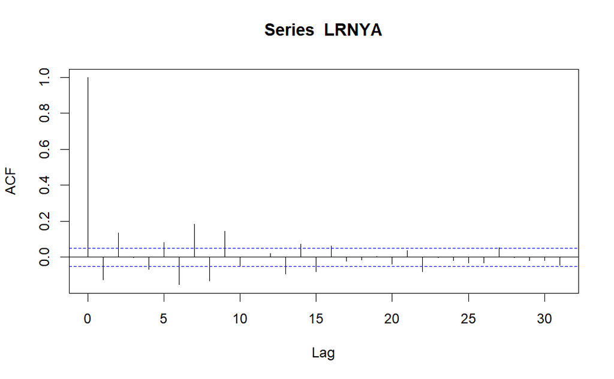

```r
acf(LRNYA)
```

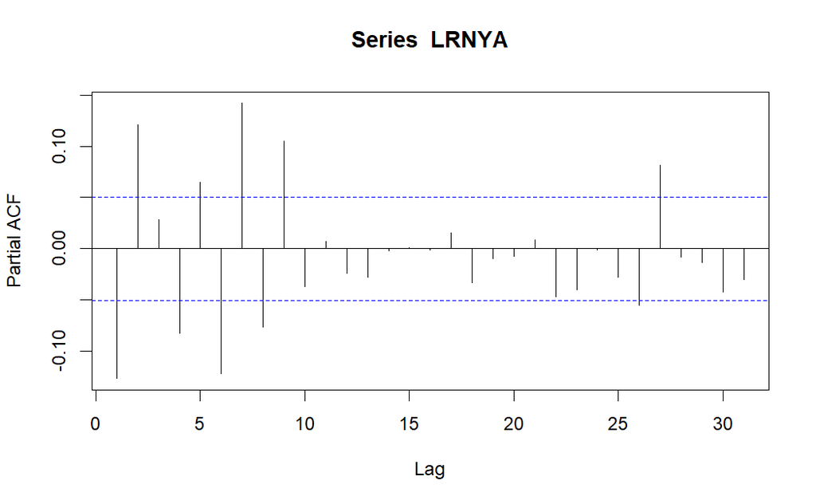

```r
pacf(LRNYA)
```

```r
#Using Auto arima
arma_pq_LRNYA = auto.arima(LRNYA)
arma_pq_LRNYA
```

```
Series: LRNYA
ARIMA(0,0,2) with zero mean

Coefficients:
          ma1     ma2
      -0.1092  0.1463
s.e.   0.0254  0.0259

sigma^2 = 0.000149:  log likelihood = 4505.09
AIC=-9004.17   AICc=-9004.16   BIC=-8988.22
```

```r
#Application of ARIMA

model4 = arima(LRNYA,order = c(0,0,2))
model4
```

```
Call:
arima(x = LRNYA, order = c(0, 0, 2))

Coefficients:
          ma1     ma2  intercept
      -0.1093  0.1462      2e-04
s.e.   0.0254  0.0259      3e-04

sigma^2 estimated as 0.0001488:  log likelihood = 4505.24,  aic = -9002.47
```

```r
et = residuals(model4)
et
```

```
Time Series:
Start = 1
End = 1508
Frequency = 1
   [1]  3.976758e-03  5.739608e-03  5.582012e-03  4.524114e-04 -4.483584e-04 -1.378274e-03
   [7]  7.654086e-03  7.165566e-03 -4.088855e-03  6.263224e-03 -1.630651e-03  3.863823e-03
  [13]  6.881669e-03  2.880384e-04  1.335298e-03  2.967471e-04  8.821129e-03 -7.530332e-03
  [19] -1.337838e-02 -1.103889e-03  2.704895e-03 -2.213517e-02 -4.293981e-02  1.199166e-02
  [25]  2.827462e-03 -3.500253e-02  6.538147e-03  1.801446e-02  1.970592e-03  1.101859e-02
  [31]  9.343761e-03  5.933244e-04 -1.013881e-02 -6.699436e-03  1.848959e-03  1.447212e-02
  [37]  1.006011e-02 -1.516712e-02 -1.639265e-02 -1.038545e-02  4.214410e-03  1.152787e-02
  [43]  3.619641e-03 -2.548649e-03  2.001094e-03  1.395943e-02 -5.254036e-04 -7.455693e-03
  [49] -6.313647e-03 -1.272300e-03  3.801325e-03 -1.002792e-02 -8.669382e-04  2.781193e-03
  [55] -2.419748e-02 -1.949421e-02  2.198801e-02 -5.484619e-03 -3.473730e-03  1.180803e-02
  [61] -1.745990e-02  8.420668e-03  1.129903e-02  8.253676e-03 -1.880966e-02 -8.973889e-04
```

[output cut: 157 more lines]

```r
#Checking of significance of ARMA
install.packages("e1071")
coeftest(model4)
```

```
z test of coefficients:

             Estimate  Std. Error z value  Pr(>|z|)
ma1       -0.10933041  0.02537274 -4.3090 1.640e-05 ***
ma2        0.14615791  0.02589167  5.6450 1.652e-08 ***
intercept  0.00017723  0.00032665  0.5426    0.5874
---
Signif. codes:  0 ‘***’ 0.001 ‘**’ 0.01 ‘*’ 0.05 ‘.’ 0.1 ‘ ’ 1
```

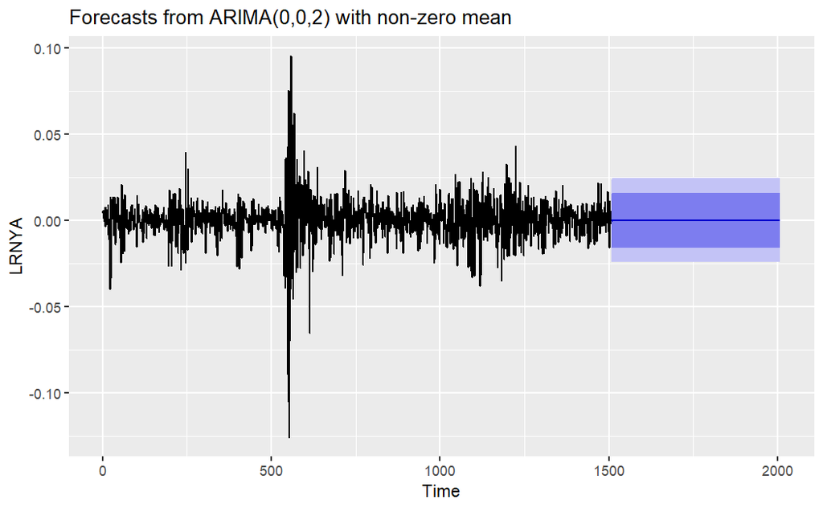

```r
install.packages("FinTS")
#point forecast is called out of sample forecast
autoplot(forecast(model4, h=500))
```

```
    Ljung-Box test

data:  Residuals from ARIMA(0,0,2) with non-zero mean
Q* = 84.202, df = 8, p-value = 6.994e-15

Model df: 2.   Total lags used: 10
```

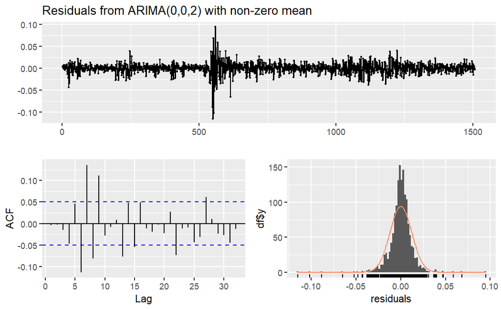

```r
#checking autocorrelation in error term
checkresiduals(model4) #there is autocorrelation in the error term
```

1. **Auto ARIMA:** gave order of ARIMA (0,0,2)

   i.e. no autoregressive (AR) terms, no differencing (D) terms, and 2nd moving average (MA) order.
2. **sigma^2:** 0.0001488. This is the estimated variance of the residuals, representing the model’s ability to fit the data.

   **Log likelihood:** 4505.24. A higher log likelihood indicates a better fit.

   **AIC:** -9002.47. A lower AIC indicates a better model.

   **Implication:** The ARIMA(0,0,2) model provides a parsimonious representation of the LRNYA time series. The model suggests that the current value of the series is influenced by the previous two errors.
3. **The significance test** The z-tests indicate that both the MA1 and MA2 coefficients are statistically significant in the ARIMA(0,0,2) model. This suggests that the current value of the series is significantly influenced by the previous two errors. The intercept coefficient is not statistically significant, indicating that the series has a mean close to zero.
4. **Autocorrelation Test:**

   Ljung Box Test:

   H0: There is no autocorrelation in error term

   H1: There is autocorrelation in error term

   p-value < 0.05 suggests that there is autocorrelation in error term of the series.
   5. **N100**

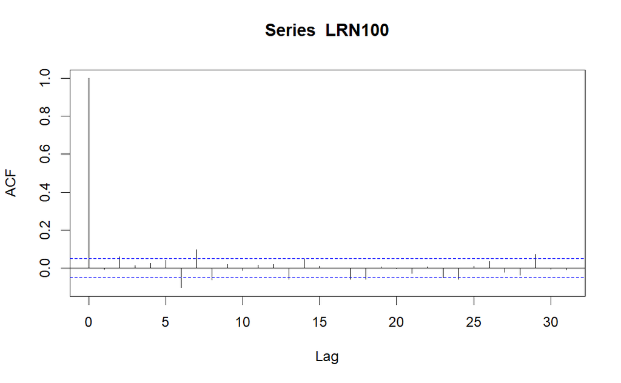

```r
acf(LRN100)
```

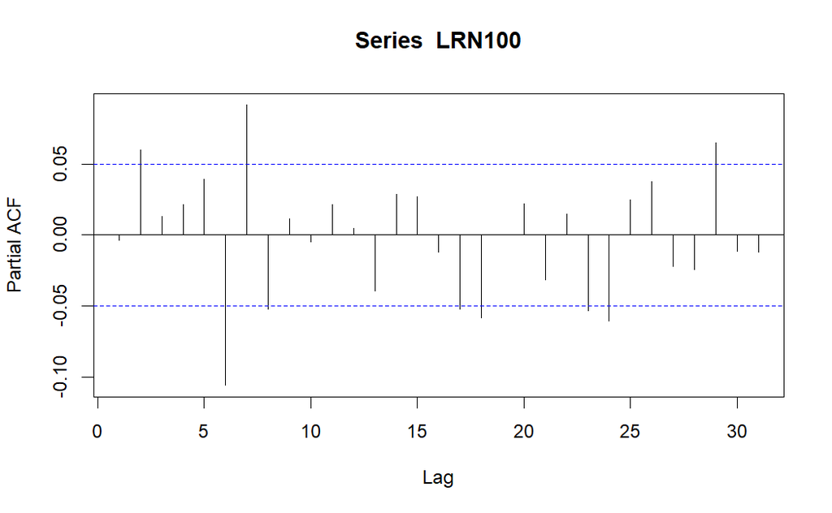

```r
pacf(LRN100)
```

```r
#Using Auto arima
arma_pq_LRN100 = auto.arima(LRN100)
arma_pq_LRN100
```

```
Series: LRN100
ARIMA(0,0,0) with zero mean

sigma^2 = 0.0001351:  log likelihood = 4662.72
AIC=-9323.44   AICc=-9323.44   BIC=-9318.11
```

```r
#Application of ARIMA

model5 = arima(LRN100,order = c(0,0,0))
model5
```

```
Call:
arima(x = LRN100, order = c(0, 0, 0))

Coefficients:
      intercept
          2e-04
s.e.      3e-04

sigma^2 estimated as 0.0001351:  log likelihood = 4662.94,  aic = -9321.89
```

```r
et = residuals(model5)
et
```

[output not shown]

[output cut: 157 more lines]

```r
#Checking of significance of ARMA
coeftest(model5)
```

```
z test of coefficients:

            Estimate Std. Error z value Pr(>|z|)
intercept 0.00019735 0.00029768   0.663   0.5074
```

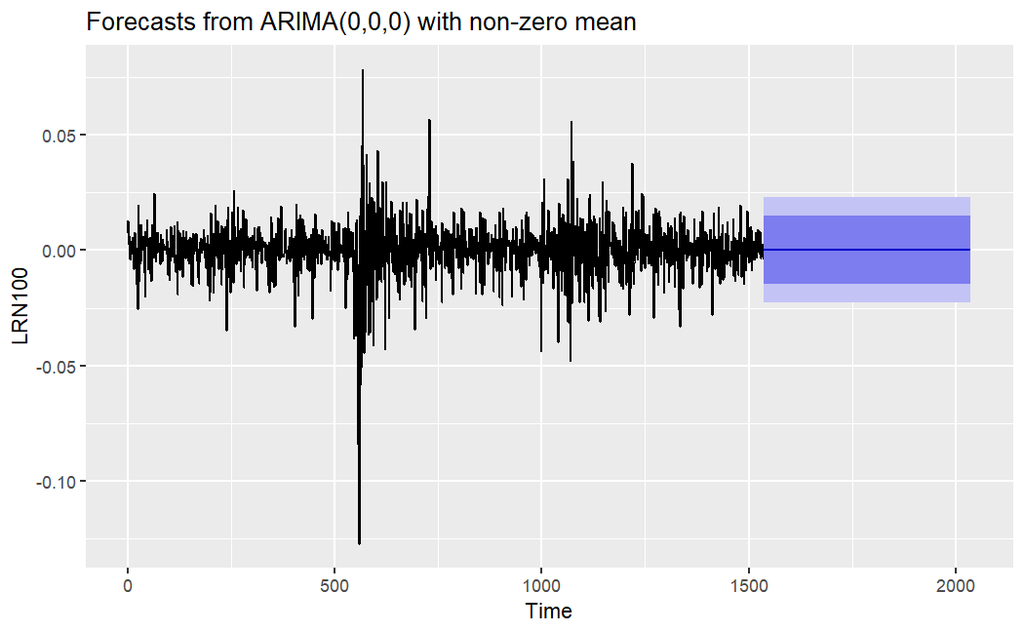

```r
#point forecast is called out of sample forecast
autoplot(forecast(model5, h=500))
```

```
    Ljung-Box test

data:  Residuals from ARIMA(0,0,0) with non-zero mean
Q* = 46.505, df = 10, p-value = 1.162e-06

Model df: 0.   Total lags used: 10
```

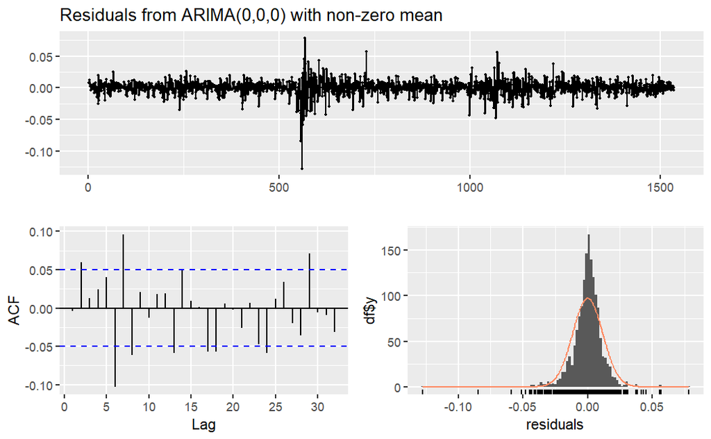

```r
#checking autocorrelation in error term
checkresiduals(model5) #there is autocorrelation in the error term
```

1. **Auto ARIMA:** gave order of ARIMA (0,0,0)

   no autoregressive (AR) terms, no differencing (D) terms, and no moving average (MA) terms.
2. **sigma^2:** 0.0001351. This is the estimated variance of the residuals, representing the model’s ability to fit the data.

   **Log likelihood:** 4662.94. A higher log likelihood indicates a better fit.

   **AIC:** -9321.89. A lower AIC indicates a better model.

   Ljung Box Test:

   H0: There is no autocorrelation in error term

   H1: There is autocorrelation in error term

   p-value < 0.05 suggests that there is autocorrelation in error term of the series.

**Linearity Test:**

**Used Test:** BDS Test

**H0:** There is linearity in log returns of series

**H1:** There is no linearity in log returns of series

```r
#Linearity Test
bds.test(LRNSEI) #Non Linear
```

```
     BDS Test

data:  LRNSEI

Embedding dimension =  2 3

Epsilon for close points =  0.0058 0.0116 0.0174 0.0231

Standard Normal =
      [ 0.0058 ] [ 0.0116 ] [ 0.0174 ] [ 0.0231 ]
[ 2 ]    10.7986    10.3742    11.9595    13.7839
[ 3 ]    13.6404    12.7886    13.8344    15.6696

p-value =
      [ 0.0058 ] [ 0.0116 ] [ 0.0174 ] [ 0.0231 ]
[ 2 ]          0          0          0          0
[ 3 ]          0          0          0          0
```

```r
bds.test(LRGSPC) #Non Linear
```

```
     BDS Test

data:  LRGSPC

Embedding dimension =  2 3

Epsilon for close points =  0.0065 0.0131 0.0196 0.0261

Standard Normal =
      [ 0.0065 ] [ 0.0131 ] [ 0.0196 ] [ 0.0261 ]
[ 2 ]    10.2639    10.3889    11.3072    12.6351
[ 3 ]    16.1656    14.8205    14.7769    15.6305

p-value =
      [ 0.0065 ] [ 0.0131 ] [ 0.0196 ] [ 0.0261 ]
[ 2 ]          0          0          0          0
[ 3 ]          0          0          0          0
```

```r
bds.test(LRHSI) #Non Linear
```

```
     BDS Test

data:  LRHSI

Embedding dimension =  2 3

Epsilon for close points =  0.0072 0.0144 0.0216 0.0288

Standard Normal =
      [ 0.0072 ] [ 0.0144 ] [ 0.0216 ] [ 0.0288 ]
[ 2 ]     0.4446     1.2127     2.7394     4.7064
[ 3 ]     1.3701     2.2145     3.7766     5.9738

p-value =
      [ 0.0072 ] [ 0.0144 ] [ 0.0216 ] [ 0.0288 ]
[ 2 ]     0.6566     0.2252     0.0062          0
[ 3 ]     0.1707     0.0268     0.0002          0
```

```r
bds.test(LRNYA) #Non Linear
```

```
     BDS Test

data:  LRNYA

Embedding dimension =  2 3

Epsilon for close points =  0.0062 0.0124 0.0186 0.0248

Standard Normal =
      [ 0.0062 ] [ 0.0124 ] [ 0.0186 ] [ 0.0248 ]
[ 2 ]    10.8812    11.9120    12.9350    14.2364
[ 3 ]    15.0962    15.4405    16.0234    16.8810

p-value =
      [ 0.0062 ] [ 0.0124 ] [ 0.0186 ] [ 0.0248 ]
[ 2 ]          0          0          0          0
[ 3 ]          0          0          0          0
```

```r
bds.test(LRN100) #Non Linear
```

```
     BDS Test

data:  LRN100

Embedding dimension =  2 3

Epsilon for close points =  0.0058 0.0116 0.0174 0.0233

Standard Normal =
      [ 0.0058 ] [ 0.0116 ] [ 0.0174 ] [ 0.0233 ]
[ 2 ]     9.4712     9.1370     9.0274     8.9367
[ 3 ]    13.4175    12.0955    11.1530    10.8504

p-value =
      [ 0.0058 ] [ 0.0116 ] [ 0.0174 ] [ 0.0233 ]
[ 2 ]          0          0          0          0
[ 3 ]          0          0          0          0
```

**Explanation:**

Implication: Since series is not linear, a SETAR model might be a more appropriate choice for modeling the log return series. The SETAR model can capture the non-linear relationships and threshold effects present in the data.

```r
VARselect(LRNSEI)
```

```
$selection
AIC(n)  HQ(n)  SC(n) FPE(n)
    10      7      7     10

$criteria
                   1             2             3             4             5             6
AIC(n) -8.9126432303 -8.9119071483 -8.9107430126 -8.9096564090 -8.9258940520 -8.9409094435
HQ(n)  -8.9099514330 -8.9078694523 -8.9053594180 -8.9029269157 -8.9178186600 -8.9314881529
SC(n)  -8.9054259140 -8.9010811738 -8.8963083799 -8.8916131181 -8.9042421030 -8.9156488363
FPE(n)  0.0001346754  0.0001347746  0.0001349315  0.0001350782  0.0001329026  0.0001309219
                   7             8             9            10
AIC(n) -8.9463457492 -8.9452621518 -8.9449090691 -8.9483969304
HQ(n)  -8.9355785599 -8.9331490639 -8.9314500825 -8.9335920451
SC(n)  -8.9174764838 -8.9127842283 -8.9088224874 -8.9087016905
FPE(n)  0.0001302121  0.0001303533  0.0001303994  0.0001299453
```

```
Using maximum autoregressive order for low regime: mL = 2
Using maximum autoregressive order for high regime: mH = 2
Searching on 1030 possible threshold values within regimes with sufficient ( 15% ) number of observations
Searching on  4120  combinations of thresholds ( 1030 ), thDelay ( 1 ), mL ( 2 ) and MM ( 2 )
Results of the grid search for 1 threshold
```

| thDelay | mL | mH | th | pooled-AIC |
| --- | --- | --- | --- | --- |
| 1 | 1 | 1 | -0.008217482 | -9201.941 |
| 1 | 1 | 1 | -0.008202605 | -9200.931 |
| 1 | 1 | 2 | -0.008217482 | -9200.404 |
| 1 | 1 | 1 | -0.008155577 | -9200.207 |
| 1 | 2 | 1 | -0.008217482 | -9200.008 |
| 1 | 1 | 2 | -0.008202605 | -9199.356 |
| 1 | 2 | 1 | -0.008202605 | -9199.004 |
| 1 | 1 | 1 | -0.008111271 | -9198.851 |
| 1 | 1 | 2 | -0.008155577 | -9198.681 |
| 1 | 2 | 2 | -0.008217482 | -9198.470 |

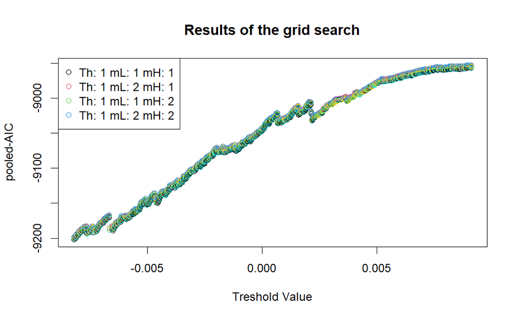

```r
#AIC lag is 10
selectSETAR(LRNSEI, m=2, thDelay = 1)
```

```r
mod.setar1 = setar(LRNSEI, m=2, thDelay = 1, th= -0.008217482)
summary(mod.setar1)
```

```
Non linear autoregressive model

SETAR model ( 2 regimes)
Coefficients:
Low regime:
     const.L       phiL.1       phiL.2
-0.000361643 -0.157329369 -0.021370644

High regime:
      const.H        phiH.1        phiH.2
 5.257086e-04 -8.627632e-05  2.543800e-02

Threshold:
-Variable: Z(t) = + (0) X(t)+ (1)X(t-1)
-Value: -0.008217 (fixed)
Proportion of points in low regime: 14.99%   High regime: 85.01%

Residuals:
        Min          1Q      Median          3Q         Max
-0.13028128 -0.00516171  0.00042229  0.00607226  0.08021782

Fit:
residuals variance = 0.0001327,  AIC = -13165, MAPE = 130.7%

Coefficient(s):

           Estimate  Std. Error  t value Pr(>|t|)
const.L -3.6164e-04  1.2379e-03  -0.2921 0.770216
phiL.1  -1.5733e-01  5.1346e-02  -3.0641 0.002223 **
phiL.2  -2.1371e-02  5.8365e-02  -0.3662 0.714302
const.H  5.2571e-04  3.5602e-04   1.4766 0.139985
phiH.1  -8.6276e-05  3.0251e-02  -0.0029 0.997725
phiH.2   2.5438e-02  4.0528e-02   0.6277 0.530324
---
Signif. codes:  0 ‘***’ 0.001 ‘**’ 0.01 ‘*’ 0.05 ‘.’ 0.1 ‘ ’ 1

Threshold
Variable: Z(t) = + (0) X(t) + (1) X(t-1)

Value: -0.008217 (fixed)
```

**Explanation:**

**AIC order:** 10  
**Hence Threshold value:** -0.008217482

**Implication:** The SETAR model provides a suitable framework for capturing the non-linear dynamics in the time series data. The results indicate significant differences in the dynamics between the high and low regimes, suggesting that the threshold is an important factor in understanding the series’ behavior.